DS 6030 | Fall 2024 | University of Virginia

# Homework #6: SVM and Calibration

Author

**Benton Pelczynski**

Published

October 18, 2024

# Required R packages and Directories

```r
dir_data= 'https://mdporter.github.io/teaching/data/' # data directory
library(tidyverse)  # functions for data manipulation
```

# COMPAS Recidivism Prediction

A recidivism risk model called COMPAS was the topic of a [ProPublica article](https://www.propublica.org/article/machine-bias-risk-assessments-in-criminal-sentencing/) on ML bias. Because the data and notebooks used for article was released on [github](https://github.com/propublica/compas-analysis), we can also evaluate the prediction bias (i.e., calibration).

This code will read in the *violent crime* risk score and apply the filtering used in the [analysis](https://github.com/propublica/compas-analysis/blob/master/Compas%20Analysis.ipynb).

```r
library(tidyverse)
df = read_csv("https://raw.githubusercontent.com/propublica/compas-analysis/master/compas-scores-two-years-violent.csv")

risk = df %>%
  filter(days_b_screening_arrest <= 30) %>%
  filter(days_b_screening_arrest >= -30) %>%
  filter(is_recid != -1) %>%
  filter(c_charge_degree != "O") %>%
  filter(v_score_text != 'N/A') %>%
  transmute(
    age, age_cat,
    charge = ifelse(c_charge_degree == "F", "Felony", "Misdemeanor"),
    race,
    sex,
    priors_count = priors_count...15,
    score = v_decile_score,              # the risk score {1,2,...,10}
    outcome = two_year_recid...53        # outcome {1 = two year recidivate}
  )
```

The `risk` data frame has the relevant information for completing the problems.

# Problem 1: COMPAS risk score

## a. Risk Score and Probability (table)

Assess the predictive bias in the COMPAS risk scores by evaluating the probability of recidivism, e.g. estimate $\Pr(Y = 1 \mid \text{Score}=x)$. Use any reasonable techniques (including Bayesian) to estimate the probability of recidivism for each risk score.

Specifically, create a table (e.g., data frame) that provides the following information:

- The COMPASS risk score.
- The point estimate of the probability of recidivism for each risk score.
- 95% confidence or credible intervals for the probability (e.g., Using normal theory, bootstrap, or Bayesian techniques).

Indicate the choices you made in estimation (e.g., state the prior if you used Bayesian methods).

**Solution**

I chose to use the Jeffreys interval formula, with the prior of $Beta(0.5, 0.5)$, for the 95% credible interval estimation.

```r
pos = aggregate(risk$outcome, by=list(risk$score), FUN=sum)
risk_prob = data.frame(table(risk$score)) %>%
  mutate(low_CI = qbeta(0.025, pos$x + 0.5, Freq - pos$x + 0.5)) %>%
  mutate(high_CI = qbeta(0.975, pos$x + 0.5, Freq - pos$x+ 0.5)) %>%
  mutate(Freq = pos$x/Freq) %>%
  rename(risk_score = Var1, point_estimate = Freq)

risk_prob
```

```
   risk_score point_estimate low_CI high_CI
1           1         0.0619 0.0500  0.0758
2           2         0.0932 0.0723  0.1180
3           3         0.1713 0.1414  0.2047
4           4         0.1765 0.1418  0.2157
5           5         0.1846 0.1453  0.2295
6           6         0.2833 0.2346  0.3362
7           7         0.3153 0.2543  0.3815
8           8         0.4344 0.3489  0.5231
9           9         0.5636 0.4703  0.6537
10         10         0.4681 0.3309  0.6091
```

## b. Risk Score and Probability (plot)

Make a plot of the risk scores and corresponding estimated probability of recidivism.

- Put the risk score on the x-axis and estimate probability of recidivism on y-axis.
- Add the 95% confidence or credible intervals calculated in part a.
- Comment on the patterns you see.

**Solution**

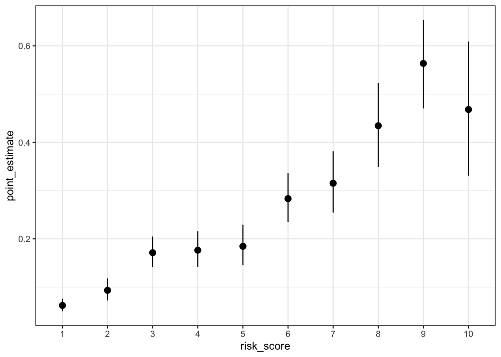

```r
ggplot(risk_prob, aes(x=risk_score, y=point_estimate)) + geom_pointrange(aes(ymin=low_CI, ymax=high_CI))
```

Overall the estimated probability of recidivism compared to risk scores roughly matches expectations; the higher the risk score, the more likely the subject is to recidivate. The major exception is risk scores 3, 4, and 5, which are almost identical; this suggests that there isn’t actually much difference in this low-to-mid range, and what separates these scores is ultimately arbitrary. Additionally, the highest risk scores have a very large about of variance in their 95% credible interval (which probably explains why, according to point estimate, 9s are more likely to recidivate than 10s), suggesting that more data would need to be collected on these high-risk subjects to present an accurate likelihood of their recidivism.

## c. Risk Score and Probability (by race)

Repeat the analysis, but this time do so for every race. Produce a set of plots (one per race) and comment on the patterns.

**Solution**

```r
data.frame(table(risk$race))
```

```
              Var1 Freq
1 African-American 1918
2            Asian   26
3        Caucasian 1459
4         Hispanic  355
5  Native American    7
6            Other  255
```

```
   risk_score point_estimate low_CI high_CI
1           1         0.0785 0.0550   0.108
2           2         0.0952 0.0656   0.133
3           3         0.1978 0.1543   0.248
4           4         0.1717 0.1275   0.224
5           5         0.2270 0.1712   0.291
6           6         0.3089 0.2466   0.377
7           7         0.3453 0.2701   0.427
8           8         0.4253 0.3252   0.530
9           9         0.5696 0.4596   0.675
10         10         0.5135 0.3566   0.668
```

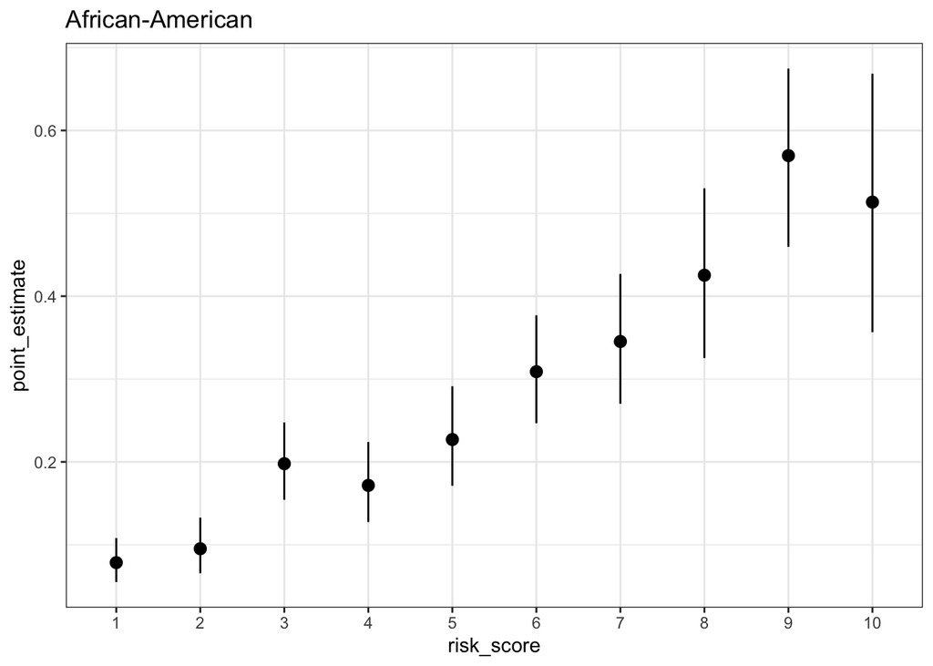

```
  risk_score point_estimate   low_CI high_CI
1          1            0.0 3.22e-05   0.152
2          2            0.0 2.17e-04   0.667
3          3            0.0 3.86e-04   0.853
4          4            0.0 1.15e-04   0.445
5          5            1.0 1.47e-01   1.000
6          6            0.5 6.08e-02   0.939
7          8            1.0 1.47e-01   1.000
```

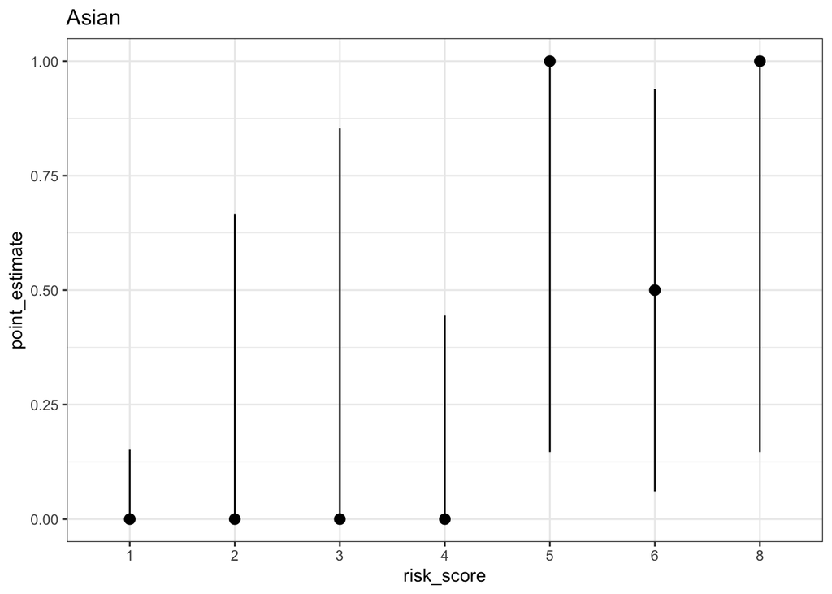

```
   risk_score point_estimate low_CI high_CI
1           1         0.0624 0.0458  0.0828
2           2         0.0814 0.0508  0.1230
3           3         0.1347 0.0921  0.1882
4           4         0.1984 0.1361  0.2744
5           5         0.1383 0.0798  0.2186
6           6         0.2500 0.1612  0.3585
7           7         0.2826 0.1686  0.4230
8           8         0.3000 0.1361  0.5172
9           9         0.5000 0.3096  0.6904
10         10         0.3333 0.0768  0.7136
```

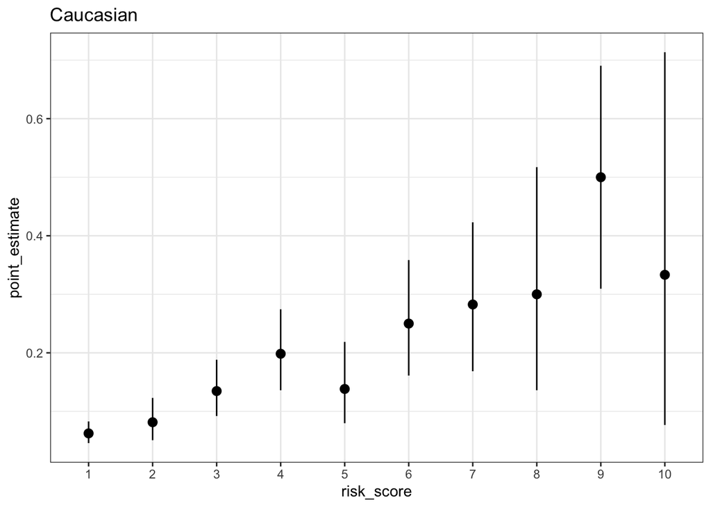

```
   risk_score point_estimate   low_CI high_CI
1           1         0.0387 1.63e-02   0.078
2           2         0.1833 1.02e-01   0.295
3           3         0.1136 4.47e-02   0.231
4           4         0.1200 3.50e-02   0.287
5           5         0.0968 2.80e-02   0.236
6           6         0.1000 2.14e-02   0.284
7           7         0.0000 5.31e-05   0.238
8           8         0.4286 1.39e-01   0.765
9           9         0.6667 1.77e-01   0.961
10         10         0.0000 3.86e-04   0.853
```

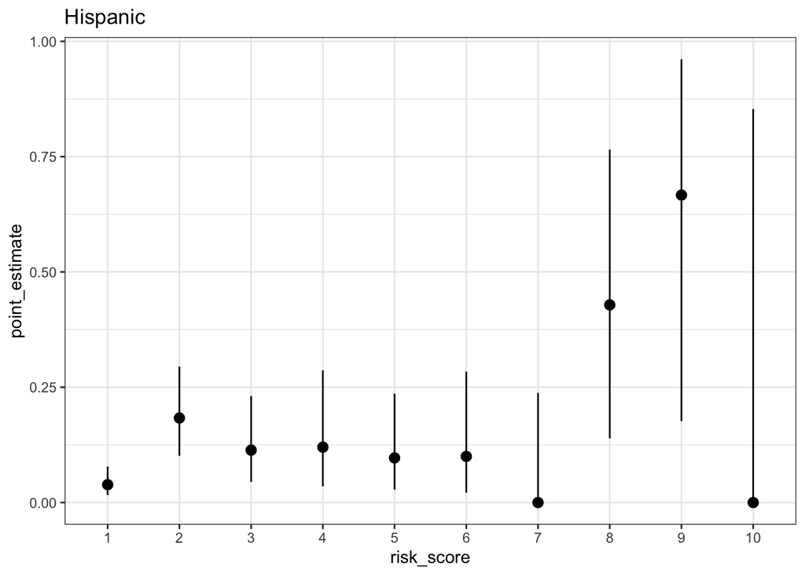

```
  risk_score point_estimate   low_CI high_CI
1          1              0 0.000217   0.667
2          2              0 0.000386   0.853
3          4              0 0.000217   0.667
4          6              0 0.000386   0.853
5          9              1 0.146746   1.000
```

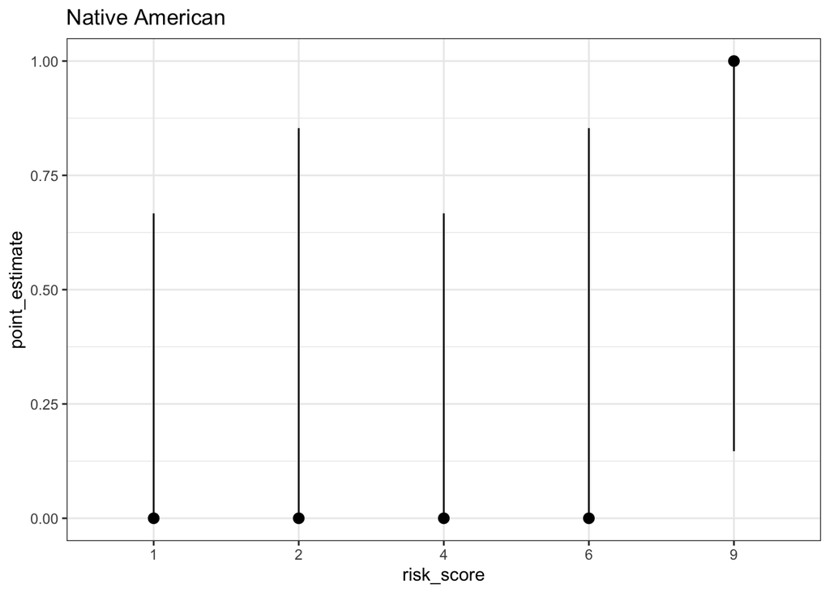

```
   risk_score point_estimate  low_CI high_CI
1           1         0.0431 0.01663  0.0919
2           2         0.0227 0.00246  0.1013
3           3         0.2593 0.12417  0.4429
4           4         0.2222 0.08002  0.4458
5           5         0.0714 0.00782  0.2884
6           6         0.3571 0.15149  0.6155
7           7         0.3333 0.10421  0.6522
8           8         0.8571 0.49920  0.9841
9           9         0.6667 0.17674  0.9613
10         10         0.3333 0.03875  0.8233
```

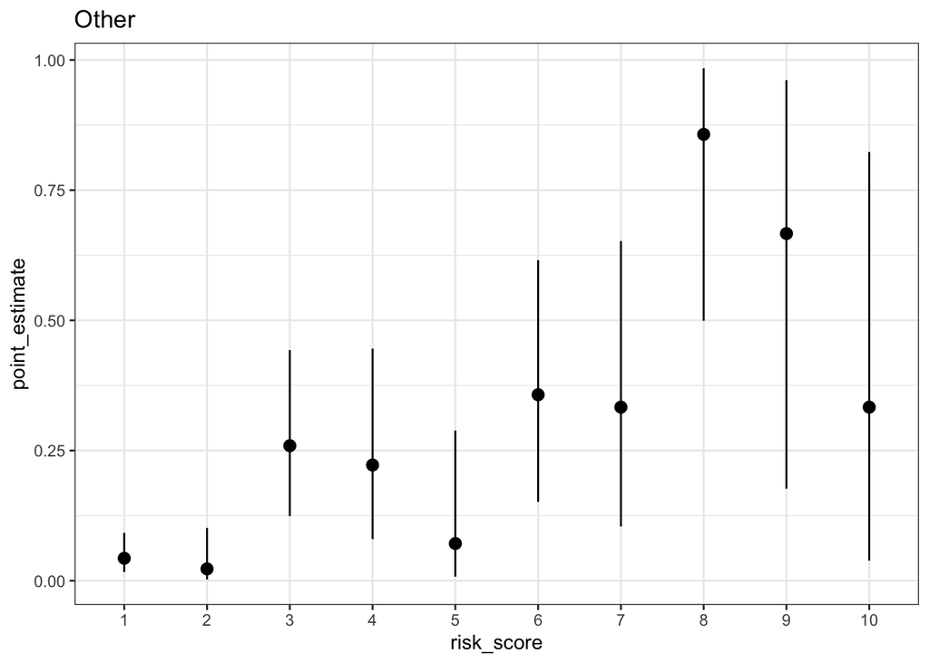

```r
for(i in data.frame(table(risk$race))$Var1){
  race_risk = filter(risk, risk$race == i)
  pos = aggregate(race_risk$outcome, by=list(race_risk$score), FUN=sum)
  risk_prob = data.frame(table(race_risk$score)) %>%
    mutate(low_CI = qbeta(0.025, pos$x + 0.5, Freq - pos$x + 0.5)) %>%
    mutate(high_CI = qbeta(0.975, pos$x + 0.5, Freq - pos$x+ 0.5)) %>%
    mutate(Freq = pos$x/Freq) %>%
    rename(risk_score = Var1, point_estimate = Freq)

  print(risk_prob)
  print(ggplot(risk_prob, aes(x=risk_score, y=point_estimate)) + geom_pointrange(aes(ymin=low_CI, ymax=high_CI))+ggtitle(i))
}
```

## d. ROC Curves

Use the raw COMPAS risk scores to make a ROC curve for each race.

- Are the best discriminating models the ones you expected?
- Are the ROC curves helpful in evaluating the COMPAS risk score?

**Solution**

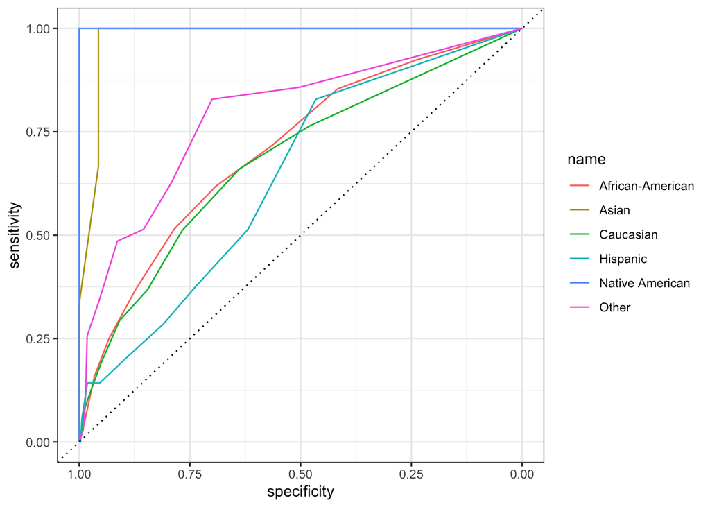

```r
library(pROC)
roc_list = list()
for(i in data.frame(table(risk$race))$Var1){
  risk_roc=roc(filter(risk, race==i)$outcome, filter(risk, race==i)$score)
  roc_list[[i]] = risk_roc
}
ggroc(roc_list)+geom_abline(slope=1,intercept=1,linetype=3)
```

# Problem 2: Support Vector Machines (SVM)

Focus on Problem 1, we won’t have an SVM problem this week.